# **Problem Statement**

#### Individual store performance

##### OUT004 - Most dominant store

```python
#statistical summary of store
kart[kart['Store_Id']=='OUT004'].describe()
```

|  | Product_Weight | Product_Allocated_Area | Product_MRP | Store_Establishment_Year | Product_Store_Sales_Total |
| --- | --- | --- | --- | --- | --- |
| count | 4676.000000 | 4676.000000 | 4676.000000 | 4676.0 | 4676.000000 |
| mean | 12.349613 | 0.069092 | 142.399709 | 2009.0 | 3299.312111 |
| std | 1.428199 | 0.048584 | 17.513973 | 0.0 | 468.271692 |
| min | 7.340000 | 0.004000 | 83.040000 | 2009.0 | 1561.060000 |
| 25% | 11.370000 | 0.031000 | 130.540000 | 2009.0 | 2942.085000 |
| 50% | 12.370000 | 0.056000 | 142.820000 | 2009.0 | 3304.180000 |
| 75% | 13.302500 | 0.097000 | 154.192500 | 2009.0 | 3646.907500 |
| max | 17.790000 | 0.297000 | 197.660000 | 2009.0 | 5462.860000 |

```python
kart[kart['Store_Id'] == 'OUT004']['Product_Store_Sales_Total'].sum()
```

```
np.float64(15427583.43)
```

```python
#best performing product categories of store OUT004
sales_by_product_type = kart[kart['Store_Id'] == 'OUT004'].groupby('Product_Type')['Product_Store_Sales_Total'].sum().sort_values(ascending=False)

print("Best performing product categories for OUT004:")
display(sales_by_product_type.head())
```

```
Best performing product categories for OUT004:
```

| Product_Type | Product_Store_Sales_Total |
| --- | --- |
| Fruits and Vegetables | 2311899.66 |
| Snack Foods | 2009026.70 |
| Frozen Foods | 1473519.65 |
| Household | 1324721.50 |
| Dairy | 1318447.30 |

**dtype:** float64

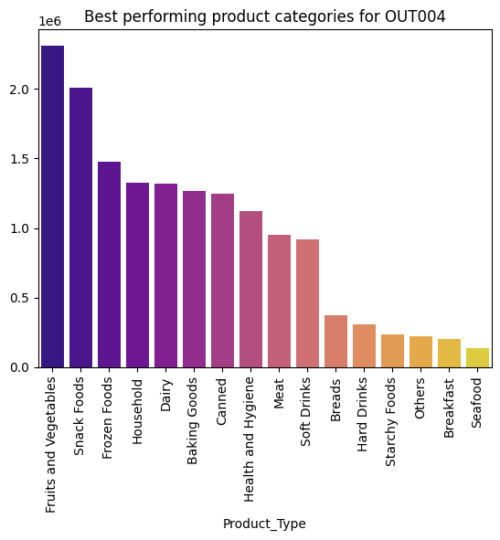

```python
sns.barplot(x=sales_by_product_type.index, y=sales_by_product_type.values, palette='plasma');
plt.title('Best performing product categories for OUT004')
x_labels=plt.xticks(rotation=90)
```

#### Observation -

- Best revenue generating category for the store OUT004 is Fruits and vegetables. It generates revenue of 2.3 million.
- Snacks best revenue generating category is snacks food with 2.0 million and third is frozen food is 1.4 million.

#### Store Id OUT003

```python
#best performing product categories of store OUT003
sales_by_product_type2 = kart[kart['Store_Id'] == 'OUT003'].groupby('Product_Type')['Product_Store_Sales_Total'].sum().sort_values(ascending=False)

print("Best performing product categories for OUT003:")
display(sales_by_product_type2.head())
```

```
Best performing product categories for OUT003:
```

| Product_Type | Product_Store_Sales_Total |
| --- | --- |
| Snack Foods | 918510.44 |
| Fruits and Vegetables | 897437.46 |
| Dairy | 715814.94 |
| Frozen Foods | 597608.42 |
| Household | 523981.64 |

**dtype:** float64

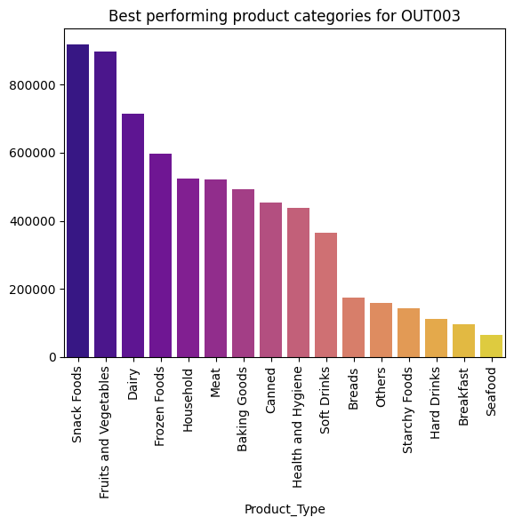

```python
#barplot for the store OUT003
sns.barplot(x=sales_by_product_type2.index, y=sales_by_product_type2.values, palette='plasma');
plt.title('Best performing product categories for OUT003')
x_labels=plt.xticks(rotation=90)
```

#### Observation for OUT003

- Best revenue generating product category for OUT003 is snack foods with .9 million.
- Fruits and Vegetables are the second best revenue generating category for the store OUT 003.

#### Store OUT002

```python
#best performing product categories of store OUT002
sales_by_product_type3 = kart[kart['Store_Id'] == 'OUT002'].groupby('Product_Type')['Product_Store_Sales_Total'].sum().sort_values(ascending=False)

print("Best performing product categories for OUT002:")
display(sales_by_product_type3.head())
```

```
Best performing product categories for OUT002:
```

| Product_Type | Product_Store_Sales_Total |
| --- | --- |
| Fruits and Vegetables | 298503.56 |
| Snack Foods | 255317.57 |
| Household | 184665.65 |
| Frozen Foods | 180295.95 |
| Dairy | 178888.18 |

**dtype:** float64

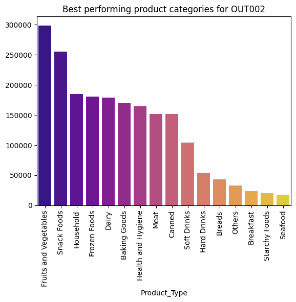

```python
#barplot for the store OUT002
sns.barplot(x=sales_by_product_type3.index, y=sales_by_product_type3.values, palette='plasma');
plt.title('Best performing product categories for OUT002')
x_labels=plt.xticks(rotation=90)
```

#### Observation OUT002

- Fruits and Vegetables is best revenue generating category at store OUT002. It is generating 0.3 million revenue.

#### Store Id OUT001

```python
#best performing product categories of store OUT001
sales_by_product_type4 = kart[kart['Store_Id'] == 'OUT001'].groupby('Product_Type')['Product_Store_Sales_Total'].sum().sort_values(ascending=False)

print("Best performing product categories for OUT001:")
display(sales_by_product_type4.head())
```

```
Best performing product categories for OUT001:
```

| Product_Type | Product_Store_Sales_Total |
| --- | --- |
| Snack Foods | 806142.24 |
| Fruits and Vegetables | 792992.59 |
| Dairy | 598767.62 |
| Frozen Foods | 558556.81 |
| Household | 531371.38 |

**dtype:** float64

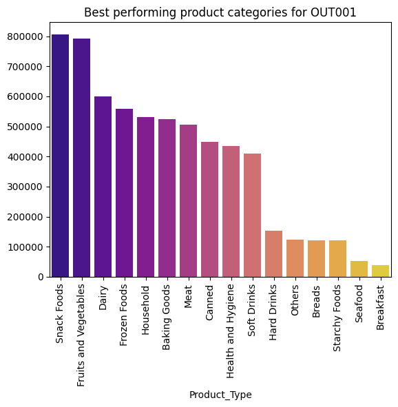

```python
#barplot for the store OUT001
sns.barplot(x=sales_by_product_type4.index, y=sales_by_product_type4.values, palette='plasma');
plt.title('Best performing product categories for OUT001')
x_labels=plt.xticks(rotation=90)
```

#### Observation for Store OUT001 -

- Snack foods are the best revenue generating product category for store OUT001 with revenue of 0.8 million.

#### Total revenue generation of different store based on sugar content

```python
#Total revenue of sugar products by store id
kart.groupby(["Product_Sugar_Content", "Store_Id"], as_index=False)["Product_Store_Sales_Total"].sum()
```

|  | Product_Sugar_Content | Store_Id | Product_Store_Sales_Total |
| --- | --- | --- | --- |
| 0 | Low Sugar | OUT001 | 3300834.93 |
| 1 | Low Sugar | OUT002 | 1156758.85 |
| 2 | Low Sugar | OUT003 | 3706903.24 |
| 3 | Low Sugar | OUT004 | 8658908.78 |
| 4 | No Sugar | OUT001 | 1090353.78 |
| 5 | No Sugar | OUT002 | 382162.19 |
| 6 | No Sugar | OUT003 | 1123084.57 |
| 7 | No Sugar | OUT004 | 2674343.14 |
| 8 | Regular | OUT001 | 1831924.47 |
| 9 | Regular | OUT002 | 491988.68 |
| 10 | Regular | OUT003 | 1843469.76 |
| 11 | Regular | OUT004 | 4094331.51 |

#### Observation -

- Low sugar content product generates highest revenue in store OUT001.

# **Data Preprocessing**

#### Feature Engineering -

- **Sugar Content** - 'reg' sugar category change 'Regular'. -- Done
- Categorize product category to perishables and non perishables. --done
- Extract the first 2 letters of the product id. --done
- Find store age. --done
- Outliers --done

#### Categorizing the product categories to perishables and non-perishables

```python
#separate product type to perishables and non perishables
perishables = ['Fruits and Vegetables','Frozen Foods','Seafood','Meat','Breakfast','Breads','Dairy']
non_perishables = ['Household', 'Health and Hygiene', 'Others','Baking Goods','Canned','Soft Drinks','Hard Drinks','Starchy Foods','Snack Foods']

kart['Product_Type_Category'] = kart['Product_Type'].apply(lambda x: 'Perishables' if x in perishables else 'Non Perishables')
```

```python
kart.head()
```

|  | Product_Id | Product_Weight | Product_Sugar_Content | Product_Allocated_Area | Product_Type | Product_MRP | Store_Id | Store_Establishment_Year | Store_Size | Store_Location_City_Type | Store_Type | Product_Store_Sales_Total | Product_Type_Category |
| --- | --- | --- | --- | --- | --- | --- | --- | --- | --- | --- | --- | --- | --- |
| 0 | FD6114 | 12.66 | Low Sugar | 0.027 | Frozen Foods | 117.08 | OUT004 | 2009 | Medium | Tier 2 | Supermarket Type2 | 2842.40 | Perishables |
| 1 | FD7839 | 16.54 | Low Sugar | 0.144 | Dairy | 171.43 | OUT003 | 1999 | Medium | Tier 1 | Departmental Store | 4830.02 | Perishables |
| 2 | FD5075 | 14.28 | Regular | 0.031 | Canned | 162.08 | OUT001 | 1987 | High | Tier 2 | Supermarket Type1 | 4130.16 | Non Perishables |
| 3 | FD8233 | 12.10 | Low Sugar | 0.112 | Baking Goods | 186.31 | OUT001 | 1987 | High | Tier 2 | Supermarket Type1 | 4132.18 | Non Perishables |
| 4 | NC1180 | 9.57 | No Sugar | 0.010 | Health and Hygiene | 123.67 | OUT002 | 1998 | Small | Tier 3 | Food Mart | 2279.36 | Non Perishables |

#### Observation -

- Added new feature in the dataset as product type category with 2 choices as perishables and non perishables.

#### Extracting the first two letters of the product id

```python
#Extracting the first two letters of the product id
kart['Product_Id_char'] = kart['Product_Id'].str[:2]
kart.head()
```

|  | Product_Id | Product_Weight | Product_Sugar_Content | Product_Allocated_Area | Product_Type | Product_MRP | Store_Id | Store_Establishment_Year | Store_Size | Store_Location_City_Type | Store_Type | Product_Store_Sales_Total | Product_Type_Category | Product_Id_char |
| --- | --- | --- | --- | --- | --- | --- | --- | --- | --- | --- | --- | --- | --- | --- |
| 0 | FD6114 | 12.66 | Low Sugar | 0.027 | Frozen Foods | 117.08 | OUT004 | 2009 | Medium | Tier 2 | Supermarket Type2 | 2842.40 | Perishables | FD |
| 1 | FD7839 | 16.54 | Low Sugar | 0.144 | Dairy | 171.43 | OUT003 | 1999 | Medium | Tier 1 | Departmental Store | 4830.02 | Perishables | FD |
| 2 | FD5075 | 14.28 | Regular | 0.031 | Canned | 162.08 | OUT001 | 1987 | High | Tier 2 | Supermarket Type1 | 4130.16 | Non Perishables | FD |
| 3 | FD8233 | 12.10 | Low Sugar | 0.112 | Baking Goods | 186.31 | OUT001 | 1987 | High | Tier 2 | Supermarket Type1 | 4132.18 | Non Perishables | FD |
| 4 | NC1180 | 9.57 | No Sugar | 0.010 | Health and Hygiene | 123.67 | OUT002 | 1998 | Small | Tier 3 | Food Mart | 2279.36 | Non Perishables | NC |

```python
kart['Product_Id_char'].unique()
```

```
array(['FD', 'NC', 'DR'], dtype=object)
```

```python
#unique values for NC
non_consumables = kart[kart['Product_Id_char'] == 'NC']
non_consumables['Product_Type'].unique()
```

```
array(['Health and Hygiene', 'Household', 'Others'], dtype=object)
```

```python
#unique values for DR
drink = kart[kart['Product_Id_char'] == 'DR']
drink['Product_Type'].unique()
```

```
array(['Hard Drinks', 'Soft Drinks'], dtype=object)
```

```python
#unique values for FD
food = kart[kart['Product_Id_char'] == 'FD']
food['Product_Type'].unique()
```

```
array(['Frozen Foods', 'Dairy', 'Canned', 'Baking Goods', 'Snack Foods',
       'Meat', 'Fruits and Vegetables', 'Breads', 'Breakfast',
       'Starchy Foods', 'Seafood'], dtype=object)
```

#### Observation -

- Product Id has 3 prefixes - FD,NC and DR.
- FD stands for food related categories.
- NC stands for non consumables.
- DR stands for Drinks.

#### Store Age

```python
#finding the store age based on the store establishment year and current year
kart['Store_Age_Years'] = 2026 - kart['Store_Establishment_Year']
kart.head()
```

|  | Product_Id | Product_Weight | Product_Sugar_Content | Product_Allocated_Area | Product_Type | Product_MRP | Store_Id | Store_Establishment_Year | Store_Size | Store_Location_City_Type | Store_Type | Product_Store_Sales_Total | Product_Type_Category | Product_Id_char | Store_Age_Years |
| --- | --- | --- | --- | --- | --- | --- | --- | --- | --- | --- | --- | --- | --- | --- | --- |
| 0 | FD6114 | 12.66 | Low Sugar | 0.027 | Frozen Foods | 117.08 | OUT004 | 2009 | Medium | Tier 2 | Supermarket Type2 | 2842.40 | Perishables | FD | 17 |
| 1 | FD7839 | 16.54 | Low Sugar | 0.144 | Dairy | 171.43 | OUT003 | 1999 | Medium | Tier 1 | Departmental Store | 4830.02 | Perishables | FD | 27 |
| 2 | FD5075 | 14.28 | Regular | 0.031 | Canned | 162.08 | OUT001 | 1987 | High | Tier 2 | Supermarket Type1 | 4130.16 | Non Perishables | FD | 39 |
| 3 | FD8233 | 12.10 | Low Sugar | 0.112 | Baking Goods | 186.31 | OUT001 | 1987 | High | Tier 2 | Supermarket Type1 | 4132.18 | Non Perishables | FD | 39 |
| 4 | NC1180 | 9.57 | No Sugar | 0.010 | Health and Hygiene | 123.67 | OUT002 | 1998 | Small | Tier 3 | Food Mart | 2279.36 | Non Perishables | NC | 28 |

#### Observation -

- Created feature as **store_age_years**. This one captured the store age in years. Current year minus Store establishment year gives as store age in years.
- We will drop the store establishment year later on.

#### Outlier Check

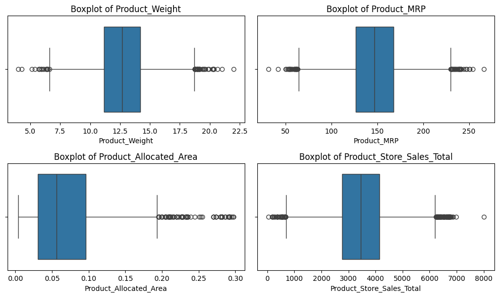

```python
#checking the outliers in all the numeric columns
cols_numeric = ['Product_Weight', 'Product_MRP', 'Product_Allocated_Area', 'Product_Store_Sales_Total']
plt.figure(figsize=(10, 6))
for index, col_name in enumerate(cols_numeric):
  plt.subplot(2, 2, index + 1)
  sns.boxplot(data=kart, x=col_name)
  plt.tight_layout()
  plt.title(f'Boxplot of {col_name}')
plt.show()
```

#### Observation for the Outliers -

- Dataset has significant amount of the outliers on the lower as well as the higher side.
- As stated earlier, we will not treat outliers as they are the genuine values.

### Data Preparation for the modelling -

#### Dropping the columns

- We have already extracted useful information from Product_Id,Product_Type and Store_Establishment_Year, so it is safe to drop them to avoid multicolinearity.
- We will also drop Store_Id as it has no meaningful relationship with the product sales.

```python
#creating the copy of the kart dataframe before data preparation for modelling
sales = kart.copy()
```

```python
#checking the data after creating dataset copy
sales.head()
```

|  | Product_Id | Product_Weight | Product_Sugar_Content | Product_Allocated_Area | Product_Type | Product_MRP | Store_Id | Store_Establishment_Year | Store_Size | Store_Location_City_Type | Store_Type | Product_Store_Sales_Total | Product_Type_Category | Product_Id_char | Store_Age_Years |
| --- | --- | --- | --- | --- | --- | --- | --- | --- | --- | --- | --- | --- | --- | --- | --- |
| 0 | FD6114 | 12.66 | Low Sugar | 0.027 | Frozen Foods | 117.08 | OUT004 | 2009 | Medium | Tier 2 | Supermarket Type2 | 2842.40 | Perishables | FD | 17 |
| 1 | FD7839 | 16.54 | Low Sugar | 0.144 | Dairy | 171.43 | OUT003 | 1999 | Medium | Tier 1 | Departmental Store | 4830.02 | Perishables | FD | 27 |
| 2 | FD5075 | 14.28 | Regular | 0.031 | Canned | 162.08 | OUT001 | 1987 | High | Tier 2 | Supermarket Type1 | 4130.16 | Non Perishables | FD | 39 |
| 3 | FD8233 | 12.10 | Low Sugar | 0.112 | Baking Goods | 186.31 | OUT001 | 1987 | High | Tier 2 | Supermarket Type1 | 4132.18 | Non Perishables | FD | 39 |
| 4 | NC1180 | 9.57 | No Sugar | 0.010 | Health and Hygiene | 123.67 | OUT002 | 1998 | Small | Tier 3 | Food Mart | 2279.36 | Non Perishables | NC | 28 |

```python
#column dropping from the sales
sales = sales.drop(['Product_Id','Product_Type','Store_Establishment_Year','Store_Id'],axis=1)
```

#### Encoding the categorical variables

```python
#displaying the categorical features
categorical_features = sales.select_dtypes(include=['object', 'category']).columns.tolist()
categorical_features
```

```
['Product_Sugar_Content',
 'Store_Size',
 'Store_Location_City_Type',
 'Store_Type',
 'Product_Type_Category',
 'Product_Id_char']
```

```python
# Create a preprocessing pipeline for the categorical features

preprocessor = make_column_transformer(
    (Pipeline([('encoder', OneHotEncoder(handle_unknown='ignore', sparse_output=False))]), categorical_features),
    remainder='passthrough'  # Leave all non-categorical columns (numerical) unchanged
)
```

```python
#printing the sales dataset to check the values
sales.head()
```

|  | Product_Weight | Product_Sugar_Content | Product_Allocated_Area | Product_MRP | Store_Size | Store_Location_City_Type | Store_Type | Product_Store_Sales_Total | Product_Type_Category | Product_Id_char | Store_Age_Years |
| --- | --- | --- | --- | --- | --- | --- | --- | --- | --- | --- | --- |
| 0 | 12.66 | Low Sugar | 0.027 | 117.08 | Medium | Tier 2 | Supermarket Type2 | 2842.40 | Perishables | FD | 17 |
| 1 | 16.54 | Low Sugar | 0.144 | 171.43 | Medium | Tier 1 | Departmental Store | 4830.02 | Perishables | FD | 27 |
| 2 | 14.28 | Regular | 0.031 | 162.08 | High | Tier 2 | Supermarket Type1 | 4130.16 | Non Perishables | FD | 39 |
| 3 | 12.10 | Low Sugar | 0.112 | 186.31 | High | Tier 2 | Supermarket Type1 | 4132.18 | Non Perishables | FD | 39 |
| 4 | 9.57 | No Sugar | 0.010 | 123.67 | Small | Tier 3 | Food Mart | 2279.36 | Non Perishables | NC | 28 |

#### Separating features and Target column

```python
# Separating features and the target column
X = sales.drop(["Product_Store_Sales_Total"], axis = 1) #dropping target variable from X
y = sales["Product_Store_Sales_Total"] #assigning the target variable to y
```

#### Target Variable -

- Our target variable is Product_Sales_Store_total.

#### Splitting the data into training and test dataset

```python
# Splitting the data into train and test sets in 80:20 ratio
X_train, X_test, y_train, y_test = train_test_split(
    X, y, test_size=.20, random_state=42, shuffle=True     #test_size is .20
)
```

```python
#checking the shape of the training and test dataset
X_train.shape, X_test.shape
```

```
((7010, 10), (1753, 10))
```

#### Observation -

- We are splitting the dataset into training and test dataset in the ratio of 80:20.
- Prior to this tried with 70:30 ratio which gave average results only.

# **Model Building**

- We will use Random Forest and XGBoost model to build our model.
- We will try to improve the model performance by hyperparameter tuning.
- We will use GridSearchCV,RandomSearchCV and R-square score to optimize our model.
- R-squared (coefficient of determination) is a key metric in regression analysis. This score indicates or explain the prediction of the target variable based on the independent variables. Higher the Rsquare score better the model.

## Define functions for Model Evaluation

```python
# function to compute adjusted R-squared
def adj_r2_score(predictors, targets, predictions):
    r2 = r2_score(targets, predictions)
    n = predictors.shape[0]
    k = predictors.shape[1]
    return 1 - ((1 - r2) * (n - 1) / (n - k - 1))


# function to compute different metrics to check performance of a regression model
def model_performance_regression(model, predictors, target):
    """
    Function to compute different metrics to check regression model performance

    model: regressor
    predictors: independent variables
    target: dependent variable
    """

    # predicting using the independent variables
    pred = model.predict(predictors)

    r2 = r2_score(target, pred)  # to compute R-squared
    adjr2 = adj_r2_score(predictors, target, pred)  # to compute adjusted R-squared
    rmse = np.sqrt(mean_squared_error(target, pred))  # to compute RMSE
    mae = mean_absolute_error(target, pred)  # to compute MAE
    mape = mean_absolute_percentage_error(target, pred)  # to compute MAPE

    # creating a dataframe of metrics
    df_perf = pd.DataFrame(
        {
            "RMSE": rmse,
            "MAE": mae,
            "R-squared": r2,
            "Adj. R-squared": adjr2,
            "MAPE": mape,
        },
        index=[0],
    )

    return df_perf
```

The ML models to be built can be any two out of the following:

1. Decision Tree
2. Bagging
3. Random Forest
4. AdaBoost
5. Gradient Boosting
6. XGBoost

#### Why Random Forest and XGBoost -

- We will be using the Random Forest and XGBoost machine learning models for creating the superkart sales prediction model.
- Both Random Forest and XGBoost are ensemble learning models who combines multiple weak models to create a robust and accurate strong model.
- Random forest is reduces overfitting, have high accuracy , can handle different data types and can provide insights into feature importance.
- XGBoost also called as extreme gradient boosting which has speed and accuracy. This model gives us highly optimized performance. It has regularization technique which prevents overfitting. It also handles missing values internally.

## Random Forest Base Model

```python
# Random Forest Regressor
rf_estimator = RandomForestRegressor(random_state=42)
rf_estimator = make_pipeline(preprocessor,rf_estimator)
rf_estimator.fit(X_train, y_train)
```

```
Pipeline(steps=[('columntransformer',
                 ColumnTransformer(remainder='passthrough',
                                   transformers=[('pipeline',
                                                  Pipeline(steps=[('encoder',
                                                                   OneHotEncoder(handle_unknown='ignore',
                                                                                 sparse_output=False))]),
                                                  ['Product_Sugar_Content',
                                                   'Store_Size',
                                                   'Store_Location_City_Type',
                                                   'Store_Type',
                                                   'Product_Type_Category',
                                                   'Product_Id_char'])])),
                ('randomforestregressor',
                 RandomForestRegressor(random_state=42))])
```

### Checking model performance on training set

```python
# random forest performance on the training set

rf_estimator_model_train_perf = model_performance_regression(rf_estimator, X_train, y_train)
rf_estimator_model_train_perf
```

|  | RMSE | MAE | R-squared | Adj. R-squared | MAPE |
| --- | --- | --- | --- | --- | --- |
| 0 | 106.732418 | 40.109366 | 0.989955 | 0.98994 | 0.014855 |

### Checking model performance on test set

```python
# random forest regressor checking performance on the test dataset

rf_estimator_model_test_perf = model_performance_regression(rf_estimator, X_test, y_test)
rf_estimator_model_test_perf
```

|  | RMSE | MAE | R-squared | Adj. R-squared | MAPE |
| --- | --- | --- | --- | --- | --- |
| 0 | 285.099561 | 109.846574 | 0.928764 | 0.928355 | 0.039388 |

#### Observation of random forest base model -

- R-squared score for the random forest base model is 0.93. This indicates good performance and the highest value of the r2 score so far.
- We will be choosing this model as the final model. This model will be used for the prediction.

## XGBoost Regressor

```python
# xgboost regressor is used

xgb_estimator = XGBRegressor(random_state=42)
xgb_estimator = make_pipeline(preprocessor,xgb_estimator)
xgb_estimator.fit(X_train, y_train)
```

```
Pipeline(steps=[('columntransformer',
                 ColumnTransformer(remainder='passthrough',
                                   transformers=[('pipeline',
                                                  Pipeline(steps=[('encoder',
                                                                   OneHotEncoder(handle_unknown='ignore',
                                                                                 sparse_output=False))]),
                                                  ['Product_Sugar_Content',
                                                   'Store_Size',
                                                   'Store_Location_City_Type',
                                                   'Store_Type',
                                                   'Product_Type_Category',
                                                   'Product_Id_char'])])),
                ('xgbregressor',
                 XGBRegressor(ba...
                              feature_types=None, feature_weights=None,
                              gamma=None, grow_policy=None,
                              importance_type=None,
                              interaction_constraints=None, learning_rate=None,
                              max_bin=None, max_cat_threshold=None,
                              max_cat_to_onehot=None, max_delta_step=None,
                              max_depth=None, max_leaves=None,
                              min_child_weight=None, missing=nan,
                              monotone_constraints=None, multi_strategy=None,
                              n_estimators=None, n_jobs=None,
                              num_parallel_tree=None, ...))])
```

### Checking model performance on training set

```python
# xgboost regressor is used

xgb_estimator_model_train_perf = model_performance_regression(xgb_estimator, X_train, y_train)
xgb_estimator_model_train_perf
```

|  | RMSE | MAE | R-squared | Adj. R-squared | MAPE |
| --- | --- | --- | --- | --- | --- |
| 0 | 134.875821 | 61.762431 | 0.983959 | 0.983936 | 0.021859 |

### Checking model performance on test set

```python
# xgboost regressor performance on the test dataset

xgb_estimator_model_test_perf = model_performance_regression(xgb_estimator, X_test, y_test)
xgb_estimator_model_test_perf
```

|  | RMSE | MAE | R-squared | Adj. R-squared | MAPE |
| --- | --- | --- | --- | --- | --- |
| 0 | 310.608484 | 137.53218 | 0.915446 | 0.914961 | 0.050081 |

- R-squared score for the XG boost model is 0.91. This indicates good performance but it is slightly less than the random forest base model and XGBoost tuned model.

# **Model Performance Improvement - Hyperparameter Tuning**

## Hyperparameter Tuning - Random Forest

```python
#tuning the random forest using hyperparameter


#Choose the type of classifier.
rf_tuned = RandomForestRegressor(random_state=42)
rf_tuned = make_pipeline(preprocessor,rf_tuned)

#Grid of parameters to choose from
parameters = {
     'randomforestregressor__max_depth':[3, 4, 5, 6],
    'randomforestregressor__max_features': ['sqrt','log2',None],
    'randomforestregressor__n_estimators': [50, 75, 100, 125, 150]
 }

#Run the grid search
grid_obj = GridSearchCV(rf_tuned, parameters, scoring='r2', cv=3, n_jobs = -1)
grid_obj = grid_obj.fit(X_train, y_train)

#Set the clf to the best combination of parameters
rf_tuned = grid_obj.best_estimator_

#Fit the best algorithm to the data.
rf_tuned.fit(X_train, y_train)
```

```
Pipeline(steps=[('columntransformer',
                 ColumnTransformer(remainder='passthrough',
                                   transformers=[('pipeline',
                                                  Pipeline(steps=[('encoder',
                                                                   OneHotEncoder(handle_unknown='ignore',
                                                                                 sparse_output=False))]),
                                                  ['Product_Sugar_Content',
                                                   'Store_Size',
                                                   'Store_Location_City_Type',
                                                   'Store_Type',
                                                   'Product_Type_Category',
                                                   'Product_Id_char'])])),
                ('randomforestregressor',
                 RandomForestRegressor(max_depth=6, max_features=None,
                                       n_estimators=50, random_state=42))])
```

### Checking model performance on training set

```python
#checking the random forest regressor performance on the training set

rf_tuned_model_train_perf = model_performance_regression(rf_tuned, X_train, y_train)
rf_tuned_model_train_perf
```

|  | RMSE | MAE | R-squared | Adj. R-squared | MAPE |
| --- | --- | --- | --- | --- | --- |
| 0 | 293.680545 | 155.055487 | 0.923946 | 0.923837 | 0.055617 |

### Checking model performance on test set

```python
#checking random forest regressor performance on the test dataset

rf_tuned_model_test_perf = model_performance_regression(rf_tuned, X_test, y_test)
rf_tuned_model_test_perf
```

|  | RMSE | MAE | R-squared | Adj. R-squared | MAPE |
| --- | --- | --- | --- | --- | --- |
| 0 | 315.032059 | 168.061714 | 0.913021 | 0.912521 | 0.059441 |

#### Observation of random forest tuned model -

- R-squared score for the random forest tuned model is 0.91. This indicates good performance but it is slightly less than the random forest base model.

## Hyperparameter Tuning - XGBoost Regressor

```python
#xgboost regressor hyperparameter tuning

import sklearn.metrics as metrics

#Choose the type of classifier.
xgb_tuned = XGBRegressor(random_state=42)
xgb_tuned = make_pipeline(preprocessor,xgb_tuned)

# # Grid of parameters to choose from
parameters = {
    'xgbregressor__n_estimators': [50, 100, 150, 200],    # number of trees to build
    'xgbregressor__max_depth': [2, 3, 4],                 # maximum depth of each tree
    'xgbregressor__colsample_bytree': [0.4, 0.5, 0.6],    # percentage of attributes to be considered (randomly) for each tree
    'xgbregressor__colsample_bylevel': [0.4, 0.5, 0.6],   # percentage of attributes to be considered (randomly) for each level of a tree
    'xgbregressor__learning_rate': [0.01, 0.05, 0.1],     # learning rate
    'xgbregressor__reg_lambda': [0.4, 0.5, 0.6],          # L2 regularization factor
     }

# Type of scoring used to compare parameter combinations
scorer = metrics.make_scorer(metrics.r2_score)

from sklearn.model_selection import RandomizedSearchCV

# # Run the grid search
grid_obj = RandomizedSearchCV(
    xgb_tuned,
    param_distributions = parameters,
    n_iter=100,
    scoring=scorer,
    cv=3,
    n_jobs=-1,
    random_state=42
)
#GridSearchCV(xgb_tuned, parameters, scoring=r2_score, cv=3, n_jobs = -1)
grid_obj = grid_obj.fit(X_train, y_train)

# # Set the clf to the best combination of parameters
xgb_tuned = grid_obj.best_estimator_

# # Fit the best algorithm to the data.
xgb_tuned.fit(X_train, y_train)
```

```
Pipeline(steps=[('columntransformer',
                 ColumnTransformer(remainder='passthrough',
                                   transformers=[('pipeline',
                                                  Pipeline(steps=[('encoder',
                                                                   OneHotEncoder(handle_unknown='ignore',
                                                                                 sparse_output=False))]),
                                                  ['Product_Sugar_Content',
                                                   'Store_Size',
                                                   'Store_Location_City_Type',
                                                   'Store_Type',
                                                   'Product_Type_Category',
                                                   'Product_Id_char'])])),
                ('xgbregressor',
                 XGBRegressor(ba...
                              feature_types=None, feature_weights=None,
                              gamma=None, grow_policy=None,
                              importance_type=None,
                              interaction_constraints=None, learning_rate=0.1,
                              max_bin=None, max_cat_threshold=None,
                              max_cat_to_onehot=None, max_delta_step=None,
                              max_depth=4, max_leaves=None,
                              min_child_weight=None, missing=nan,
                              monotone_constraints=None, multi_strategy=None,
                              n_estimators=150, n_jobs=None,
                              num_parallel_tree=None, ...))])
```

### Checking model performance on training set

```python
#checking xgboost regressor performance on training dataset

xgb_tuned_model_train_perf = model_performance_regression(xgb_tuned, X_train, y_train)
xgb_tuned_model_train_perf
```

|  | RMSE | MAE | R-squared | Adj. R-squared | MAPE |
| --- | --- | --- | --- | --- | --- |
| 0 | 273.655158 | 118.829756 | 0.933964 | 0.93387 | 0.046701 |

### Checking model performance on test set

```python
#checking xgboost regressor performance on the test dataset

xgb_tuned_model_test_perf = model_performance_regression(xgb_tuned, X_test, y_test)
xgb_tuned_model_test_perf
```

|  | RMSE | MAE | R-squared | Adj. R-squared | MAPE |
| --- | --- | --- | --- | --- | --- |
| 0 | 299.813283 | 133.219239 | 0.921221 | 0.920769 | 0.049376 |

#### Observation for XGBoost tuned -

- Rsqaured value for the XGBoost tuned model is 0.92. This is slightly less than the random forest original model.

# **Model Performance Comparison, Final Model Selection, and Serialization**

```python
 # training performance comparison

models_train_comp_df = pd.concat(
    [
        rf_estimator_model_train_perf.T,
        xgb_estimator_model_train_perf.T,
        rf_tuned_model_train_perf.T,
        xgb_tuned_model_train_perf.T,
    ],
    axis=1,
)

models_train_comp_df.columns = ["Random Forest", "XGBoost", "Random Forest Tuned", "XGBoost Tuned"]
print("Training performance comparison:")
models_train_comp_df
```

```
Training performance comparison:
```

|  | Random Forest | XGBoost | Random Forest Tuned | XGBoost Tuned |
| --- | --- | --- | --- | --- |
| RMSE | 106.732418 | 134.875821 | 293.680545 | 273.655158 |
| MAE | 40.109366 | 61.762431 | 155.055487 | 118.829756 |
| R-squared | 0.989955 | 0.983959 | 0.923946 | 0.933964 |
| Adj. R-squared | 0.989940 | 0.983936 | 0.923837 | 0.933870 |
| MAPE | 0.014855 | 0.021859 | 0.055617 | 0.046701 |

```python
 # testing performance comparison

models_test_comp_df = pd.concat(
    [
        rf_estimator_model_test_perf.T, #random forest original test performance
        xgb_estimator_model_test_perf.T, #xgb original test performance
        rf_tuned_model_test_perf.T, #random forest tuned test performance
        xgb_tuned_model_test_perf.T, #xgb tuned test performance
    ],
    axis=1,
)

models_test_comp_df.columns = ["Random Forest", "XGBoost", "Random Forest Tuned", "XGBoost Tuned"] #heading

print("Testing performance comparison:")
models_test_comp_df #printing the results for comparison
```

```
Testing performance comparison:
```

|  | Random Forest | XGBoost | Random Forest Tuned | XGBoost Tuned |
| --- | --- | --- | --- | --- |
| RMSE | 285.099561 | 310.608484 | 315.032059 | 299.813283 |
| MAE | 109.846574 | 137.532180 | 168.061714 | 133.219239 |
| R-squared | 0.928764 | 0.915446 | 0.913021 | 0.921221 |
| Adj. R-squared | 0.928355 | 0.914961 | 0.912521 | 0.920769 |
| MAPE | 0.039388 | 0.050081 | 0.059441 | 0.049376 |

#### Final Model -

- Based on all the model performance, final model chosen is Random Forest base model.
- Rsquared value for this model on test dataset is approx 0.93 which is highest among all the original and tuned models.

```python
# Create a folder for storing the files needed for web app deployment
os.makedirs("backend_files", exist_ok=True)
```

```python
# Define the file path to save (serialize) the trained model along with the data preprocessing steps
saved_model_path = "backend_files/superkart_sales_prediction_model_v1_0.joblib" # name of the model
```

```python
import joblib

# Save the best trained model pipeline using joblib with compression
joblib.dump(rf_estimator, saved_model_path, compress=True) # Enable compression

print(f"Model saved successfully at {saved_model_path}")
```

```
Model saved successfully at backend_files/superkart_sales_prediction_model_v1_0.joblib
```

```python
# Load the saved model pipeline from the file
saved_model = joblib.load("backend_files/superkart_sales_prediction_model_v1_0.joblib") #name of the saved model

# Confirm the model is loaded
print("Model loaded successfully.")
```

```
Model loaded successfully.
```

```python
saved_model
```

```
Pipeline(steps=[('columntransformer',
                 ColumnTransformer(remainder='passthrough',
                                   transformers=[('pipeline',
                                                  Pipeline(steps=[('encoder',
                                                                   OneHotEncoder(handle_unknown='ignore',
                                                                                 sparse_output=False))]),
                                                  ['Product_Sugar_Content',
                                                   'Store_Size',
                                                   'Store_Location_City_Type',
                                                   'Store_Type',
                                                   'Product_Type_Category',
                                                   'Product_Id_char'])])),
                ('randomforestregressor',
                 RandomForestRegressor(random_state=42))])
```

Let's try making predictions on the test set using the deserialized model.

- Please ensure that the saved model is loaded before making predictions.

```python
saved_model.predict(X_test) #X_test for inference
```

```
array([3429.494 , 3365.6871, 2445.7411, ..., 4161.2101, 2831.1792,
       4518.7874])
```

- As we can see, the model can be directly used for making predictions without any retraining.

# **Deployment - Backend**

- Created a GitHub account (https://github.com)
- Generated a **Personal Access Token** with repo scope
- The serialized ML model file (`superkart_sales_prediction_model_v1_0.joblib`)is present in the `backend_files` folder for pushing to GitHub
- We will deploy **both the Flask backend and the Streamlit frontend as separate Docker containers** inside a GitHub Codespace, and connect them using a **Docker network**

## Flask Web Framework

Flask is a lightweight, flexible Python web framework used to build web applications and APIs quickly and easily.

Flask allows you to:

- Create web routes (URLs that users can access)
- Handle HTTP requests and responses
- Build REST APIs to expose machine learning models or other services

```python
# Create a folder for storing the files needed for backend server deployment
import os
os.makedirs("backend_files", exist_ok=True)
```

**Note:** Once the `backend_files` folder is created, upload the model file (`superkart_sales_prediction_model_v1_0.joblib`) to it.

```python
%%writefile backend_files/app.py

# Import necessary libraries
import numpy as np
import joblib  # For loading the serialized model
import pandas as pd  # For data manipulation
from flask import Flask, request, jsonify  # For creating the Flask API

# Initialize Flask app with a name
superkart_api = Flask("SuperKart")

# Load the trained model
model = joblib.load("superkart_sales_prediction_model_v1_0.joblib")

# Define a route for the home page
@superkart_api.get('/')
def home():
    return "Welcome to the SuperKart System"

# Define an endpoint to predict sales for a single product
@superkart_api.post('/v1/predict')
def predict_sales():
    # Get JSON data from the request
    data = request.get_json()

    # Extract relevant features from the input data
    sample = {
    'Product_Weight': data['Product_Weight'],
    'Product_Sugar_Content': data['Product_Sugar_Content'],
    'Product_Allocated_Area': data['Product_Allocated_Area'],
    'Product_MRP': data['Product_MRP'],
    'Store_Size': data['Store_Size'],
    'Store_Location_City_Type': data['Store_Location_City_Type'],
    'Store_Type': data['Store_Type'],
    'Product_Id_char': data['Product_Id_char'],
    'Store_Age_Years': data['Store_Age_Years'],
    'Product_Type_Category': data['Product_Type_Category']
}

    # Convert the extracted data into a DataFrame
    input_data = pd.DataFrame([sample])

    # Make a prediction using the trained model
    prediction = model.predict(input_data).tolist()[0]

    # Return the prediction as a JSON response
    return jsonify({'Sales': prediction})

# Define an endpoint to predict sales for a batch of products
@superkart_api.post('/v1/predictbatch')
def predict_sales_batch():
    # Get the uploaded CSV file from the request
    file = request.files['file']

    # Read the file into a DataFrame
    input_data = pd.read_csv(file)

    # Make predictions for the batch data
    predictions = model.predict(input_data).tolist()

    # Create an output dictionary mapping row index to predicted sales
    output_dict = {str(i): round(pred, 2) for i, pred in enumerate(predictions)}

    return output_dict


# Run the Flask app in debug mode
if __name__ == '__main__':
    superkart_api.run(debug=True)
```

```
Overwriting backend_files/app.py
```

In the given code snippet, the decorators `@superkart_api.get('/')`, `@superkart_api.post('/v1/predict')`, and `@superkart_api.post('/v1/predictbatch')` are used in **Flask**, a web framework for building APIs in Python.

**What is a Decorator?**  
In Python, a **decorator** is a function that modifies or extends the behavior of another function. In Flask, decorators are used to **map URL routes** to Python functions.

**Summary of flow of script**

1. **Model Loading (`joblib.load`)** – Loads a pre-trained ML model (`superkart_sales_prediction_model_v1_0.joblib`) trained to predict product sales based on product and store features.
2. **Flask App Setup** – Initializes a simple Flask web server.
3. **Routes**:
   - `GET /` – Home route, returns a welcome message.
   - `POST /v1/predict` – Accepts a single product's data as JSON, returns a sales prediction.
   - `POST /v1/predictbatch` – Accepts a CSV file of multiple products, returns predictions for all rows.
4. **Running** – In production, the app is served using Gunicorn (as defined in the Dockerfile).

## Dependencies File

```python
%%writefile backend_files/requirements.txt
pandas==2.2.3
numpy==2.1.3
scikit-learn==1.6.1
xgboost==3.4.1
joblib==1.4.2
Werkzeug==3.1.8
flask==3.1.3
gunicorn==26.2.0
requests==2.32.4
uvicorn[standard]
```

```
Overwriting backend_files/requirements.txt
```

## Dockerfile

```python
%%writefile backend_files/Dockerfile
FROM python:3.12-slim

# Set the working directory inside the container
WORKDIR /app

# Copy all files from the current directory to the container's working directory
COPY . .

# Install dependencies from the requirements file without using cache to reduce image size
RUN pip install --no-cache-dir --upgrade -r requirements.txt

# Define the command to start the application using Gunicorn with 4 worker processes
# - `-w 4`: Uses 4 worker processes for handling requests
# - `-b 0.0.0.0:7860`: Binds the server to port 7860 on all network interfaces
# - `app:superkart_api`: Runs the Flask app (assuming `app.py` contains the Flask instance named `superkart_api`)
CMD ["gunicorn", "-w", "4", "-b", "0.0.0.0:7860", "app:superkart_api"]
```

```
Overwriting backend_files/Dockerfile
```

This Dockerfile is used to **containerize the Flask application**, making it easy to deploy and run consistently across different environments.

# **Deployment - Frontend**

## Comments

- The frontend Streamlit app will communicate with the backend Flask API **over a Docker network** -The Streamlit app will call `http://backend:7860` - here `backend` is the **container name** we will assign when running the Docker container, and Docker's internal DNS resolves it automatically (For example, `docker run -d --name backend --network churn-app-network -p 7860:7860 churn-backend`)
- Both containers will be launched inside the same GitHub Codespace

## Streamlit for Interactive UI

```python
# Create a folder for storing the files needed for frontend UI deployment
os.makedirs("frontend_files", exist_ok=True)
```

```python
%%writefile frontend_files/app.py

import streamlit as st
import pandas as pd
import requests

# Base URL of the Flask backend
BACKEND_URL = "http://backend:7860"

# Page title
st.title("SuperKart System")
st.write(
    "Enter the product and store details below to predict the total sales."
)

# Input fields for product and store data
Product_Weight = st.number_input("Product Weight", min_value=0.0, value=12.66)
Product_Sugar_Content = st.selectbox("Product Sugar Content", ["Low Sugar", "Regular", "No Sugar"])
Product_Allocated_Area = st.number_input("Product Allocated Area", min_value=0.0, value=0.027)
Product_MRP = st.number_input("Product MRP", min_value=0.0, value=117.08)
Store_Size = st.selectbox("Store Size", ["Small", "Medium", "High"])
Store_Location_City_Type = st.selectbox("Store Location City Type", ["Tier 1", "Tier 2", "Tier 3"])
Store_Type = st.selectbox("Store Type", ["Supermarket Type1", "Supermarket Type2", "Supermarket Type3", "Departmental Store", "Food Mart"])
Product_Id_char = st.selectbox("Product ID Character", ["FD", "DR", "NC"])
Store_Age_Years = st.number_input("Store Age (Years)", min_value=0, value=16)
Product_Type_Category = st.selectbox("Product Type Category", ["Perishables", "Non Perishables"])

# Create JSON payload
product_data = {
    "Product_Weight": Product_Weight,
    "Product_Sugar_Content": Product_Sugar_Content,
    "Product_Allocated_Area": Product_Allocated_Area,
    "Product_MRP": Product_MRP,
    "Store_Size": Store_Size,
    "Store_Location_City_Type": Store_Location_City_Type,
    "Store_Type": Store_Type,
    "Product_Id_char": Product_Id_char,
    "Store_Age_Years": Store_Age_Years,
    "Product_Type_Category": Product_Type_Category
}

# Single Prediction
if st.button("Predict", type='primary'):

    response = requests.post(
        f"{BACKEND_URL}/v1/predict",
        json=product_data
    )

    if response.status_code == 200:
        result = response.json()
        predicted_sales = result["Sales"]
        st.success(f"Predicted Product Store Sales Total: ₹{predicted_sales:.2f}")
    else:
        st.error("Unable to connect to the prediction API.")

# Batch Prediction
st.subheader("Batch Prediction")

uploaded_file = st.file_uploader(
    "Upload a CSV file",
    type=["csv"]
)

if uploaded_file is not None:

    if st.button("Predict for Batch", type='primary'):

        response = requests.post(
            f"{BACKEND_URL}/v1/predictbatch",
            files={"file": uploaded_file}
        )

        if response.status_code == 200:
            results = response.json()

            st.success("Predictions completed successfully!")

            try:
                if isinstance(results, list):
                    df = pd.DataFrame(results)
                elif isinstance(results, dict):
                    # Check if all values are scalars
                    if all(not isinstance(v, (list, dict)) for v in results.values()):
                        df = pd.DataFrame([results])
                    else:
                        df = pd.DataFrame(results)
                else:
                    df = pd.DataFrame({"Result": [results]})

                st.dataframe(df, use_container_width=True)

            except Exception as e:
                st.error(f"Unable to display results as a table: {e}")
                st.json(results)

        else:
            st.error("Unable to connect to the prediction API.")
```

```
Overwriting frontend_files/app.py
```

## Dependencies File

```python
%%writefile frontend_files/requirements.txt
pandas==2.2.3
requests==2.32.4
streamlit==1.43.2
```

```
Overwriting frontend_files/requirements.txt
```

## Dockerfile

```python
%%writefile frontend_files/Dockerfile
# Use a minimal base image compatible with the pinned dependencies
FROM python:3.12-slim

# Set the working directory inside the container to /app
WORKDIR /app

# Copy all files from the current directory on the host to the container's /app directory
COPY . .

# Install Python dependencies listed in requirements.txt
RUN pip3 install -r requirements.txt

# Define the command to run the Streamlit app on port 8501 and make it accessible externally
CMD ["streamlit", "run", "app.py", "--server.port=8501", "--server.address=0.0.0.0", "--server.enableXsrfProtection=false"]
```

```
Overwriting frontend_files/Dockerfile
```

# **Pushing Deployment Files to GitHub**

## Setting Up a GitHub Repository

The code below authenticates with your GitHub account using the Personal Access Token, creates a new public repository, and pushes all the backend and frontend files to it.

The files are pushed with a folder structure that keeps backend and frontend separate:

[output not shown]

This folder structure is important because when we open a Codespace from this repo, we will `cd` into each folder separately to build its Docker image.

## Before executing the below cell

- GitHub account is created and generated a Personal Access Token.
- Token is saved in Colab secrets.

**Secrets** in Google Colab provide a secure way to store sensitive information such as API keys, access tokens, and passwords. Instead of hardcoding these values in your notebook, you can save them as secrets and access them securely whenever needed.

```python
# Your GitHub Personal Access Token

from google.colab import userdata
GITHUB_TOKEN = userdata.get('Gittoken')  # Complete the code to replace with the secret name for your token.For example, Gittoken

# After executing this code, you may be prompted to grant access. Click "Grant Access" to continue.
```

```python
# Name for the new repository
REPO_NAME = "superkart-sales-prediction-api-v3"  # repository name

# Install PyGithub library if not already installed
!pip install PyGithub

# Authenticate with GitHub
from github import Github
from github import GithubException

g = Github(GITHUB_TOKEN)
user = g.get_user()
print(f"Authenticated as: {user.login}")

# Check if the repository already exists
try:
    repo = user.get_repo(REPO_NAME)
    print(f"Repository '{REPO_NAME}' already exists: {repo.html_url}")
except GithubException as e:
    if e.status == 404: # Not Found
        # Create the repository
        repo = user.create_repo(
            REPO_NAME,
            description="Superkart Sales Price Prediction - Flask API Backend + Streamlit Frontend (Dockerized)",
            private=False,
            auto_init=True  # Creates an initial README so the repo is not empty
        )
        print(f"Repository created successfully: {repo.html_url}")
    else:
        raise # Re-raise other GitHub exceptions


# Dictionary mapping repo file paths to local file paths
# Backend files go under backend/ and frontend files go under frontend/
files_to_push = {
    "backend/app.py": "backend_files/app.py",
    "backend/requirements.txt": "backend_files/requirements.txt",
    "backend/Dockerfile": "backend_files/Dockerfile",
    "backend/superkart_sales_prediction_model_v1_0.joblib": "backend_files/superkart_sales_prediction_model_v1_0.joblib",
    "frontend/app.py": "frontend_files/app.py",
    "frontend/requirements.txt": "frontend_files/requirements.txt",
    "frontend/Dockerfile": "frontend_files/Dockerfile",
}

for repo_path, local_path in files_to_push.items():
    # Read the file content as bytes
    with open(local_path, "rb") as f:
        content = f.read()

    # Upload the file to the repo on the main branch
    # Check if the file already exists before creating it
    try:
        # Try to get the file to see if it exists
        contents = repo.get_contents(repo_path, ref="main")
        # If it exists, update it
        repo.update_file(path=contents.path, message=f"Update {repo_path}", content=content, sha=contents.sha, branch="main")
        print(f"Updated: {repo_path}")
    except GithubException as e:
        if e.status == 404: # Not Found
            # If file doesn't exist, create it
            repo.create_file(
                path=repo_path,
                message=f"Add {repo_path}",
                content=content,
                branch="main"
            )
            print(f"Uploaded: {repo_path}")
        else:
            raise # Re-raise other GitHub exceptions

print(f"\nAll files pushed successfully to: {repo.html_url}")
```

```
Authenticated as: jain1201
Repository created successfully: https://github.com/jain1201/superkart-sales-prediction-api-v3
Uploaded: backend/app.py
Uploaded: backend/requirements.txt
Uploaded: backend/Dockerfile
Uploaded: backend/superkart_sales_prediction_model_v1_0.joblib
Uploaded: frontend/app.py
Uploaded: frontend/requirements.txt
Uploaded: frontend/Dockerfile

All files pushed successfully to: https://github.com/jain1201/superkart-sales-prediction-api-v3
```

Once the files have been successfully pushed to GitHub, the previous code cell will display an output similar to the following:

```
All files pushed successfully to: https://github.com/gllearn/superkart-sales-prediction
```

**After the files have been pushed successfully, deploy the app using GitHub Codespaces.**

# **Inferencing using Flask API**

As the **frontend and backend are decoupled**, we can **access the backend directly for predictions**.

- The decoupling ensures seamless interaction with the deployed model while leveraging the API for scalable inference.

Let's see how to interact with the deployed Flask API running inside a GitHub Codespace to perform **online** and **batch inference** from this Colab notebook.

We will:

1. Send API requests for both online and batch inference.
2. Process and check the model predictions.

```python
import json  # To handle JSON formatting for API requests and responses
import requests  # To send HTTP requests to the deployed Flask API

import pandas as pd  # For data manipulation and analysis
import numpy as np  # For numerical computations
```

```python
model_root_url = "https://friendly-space-couscous-r76rr96v6g77c6xg-7860.app.github.dev/"  #  Codespace forwarded URL for port 7860
```

```python
model_url = model_root_url + "/v1/predict"  # Endpoint for online (single) inference
```

Since our model predictions are provided by the following endpoint we created using Flask, we need to invoke the same to make prediction.

> `@superkart_api.post('/v1/predict')`

```python
model_batch_url = model_root_url + "/v1/predictbatch"  # Endpoint for batch inference
```

> `@superkart_api.post('/v1/predictbatch')`

## Online

**Online Inference:** Sending a single request to the API and receiving an immediate response. This is useful for real-time applications like recommendation systems and fraud detection.

- This data is sent as a JSON payload in a POST request to the model endpoint.
- The model processes the input features and returns a prediction.

```python
payload = {
  "Product_Weight": 12.66,
  "Product_Sugar_Content": "Low Sugar",
  "Product_Allocated_Area": 0.027,
  "Product_MRP": 117.08,
  "Store_Size": "Medium",
  "Store_Location_City_Type": "Tier 2",
  "Store_Type": "Supermarket Type2",
  "Product_Id_char": "FD",
  "Store_Age_Years": 16,
  "Product_Type_Category": "Non Perishables"
}
```

```python
# Sending a POST request to the model endpoint with the test payload
response = requests.post(model_url, json=payload)
```

```python
response
```

```
<Response [200]>
```

`<Response [200]>` indicates that the HTTP request was successful.

- `Response` is the object returned by `requests.post()`.
- `[200]` is the HTTP status code, meaning **OK** (the request was processed successfully).

```python
print(response.json())
```

```
{'Sales': 2967.104100000001}
```

`response.json()` is used to parse the response body as JSON.

- If the API returns data in JSON format, `.json()` converts it into a Python dictionary.
- This allows easy access to specific values using keys.

## Batch

**Batch Inference:** Sending multiple inputs in a single request, allowing efficient processing of large datasets. This is ideal for analyzing historical data at scale.

```python
batch_dataset = pd.read_csv("Batch_Data_SuperKart.csv")
```

**Note**: The batch CSV file must contain all the feature columns expected by the model: `Product_Weight`, `Product_Sugar_Content`, `Product_Allocated_Area`, `Product_MRP`, `Store_Size`, `Store_Location_City_Type`, `Store_Type`, `Product_Id_char`, `Store_Age_Years`, `Product_Type_Category`.

```python
# Prepare batch input for API request
batch_input = {
    'file': batch_dataset.to_csv(header=True, index=False).encode('utf-8')
}
```

This code prepares the product data as a **file-like object** to send in an API request (in the `files` parameter of `requests.post`).

- `batch_dataset`: This is a Pandas DataFrame containing the product data loaded from a CSV file.
- `.to_csv(header=True, index=False)`: Converts the DataFrame into a CSV **string**, keeping the column headers (`header=True`) but **excluding the index** (`index=False`).
- `.encode('utf-8')`: Encodes the CSV string into **bytes** (UTF-8 format), which is necessary for sending it over an HTTP request.
- `'file': ...`: Wraps the encoded CSV data in a dictionary with the key `'file'`, which is expected by the Flask backend.

```python
# Send request to the model API for batch predictions
response = requests.post(
    model_batch_url,  # Model endpoint URL
    files=batch_input
)
```

This line sends a **POST request** to the deployed model API to perform **batch sales prediction**.

- `requests.post(...)`: This uses the `requests` library to make a **POST** request to a web server (in this case, our API endpoint for batch predictions).
- `model_batch_url`: This is the URL endpoint where the batch prediction API is hosted. It should look like this:  
  `"https://<your-codespace-name>-7860.app.github.dev/v1/predictbatch"`
- `files=batch_input`: This sends the batch data file (e.g., a CSV) as part of the request using the `files` parameter.
- `response`: This is the result of the API call and contains the response from the server, including predicted sales values.

```python
response
```

```
<Response [200]>
```

```python
# Extract predictions from API response
response.text
```

```
'{"0":4198.89,"1":2892.02,"2":4027.1,"3":1879.43,"4":4029.14,"5":4910.99,"6":2525.89,"7":2343.12,"8":4623.48,"9":2665.73}\n'
```

As we can see, we receive a JSON where each key represents a row index, and the value represents the model's predicted sales for that product.

#### **App output - Single Prediction**

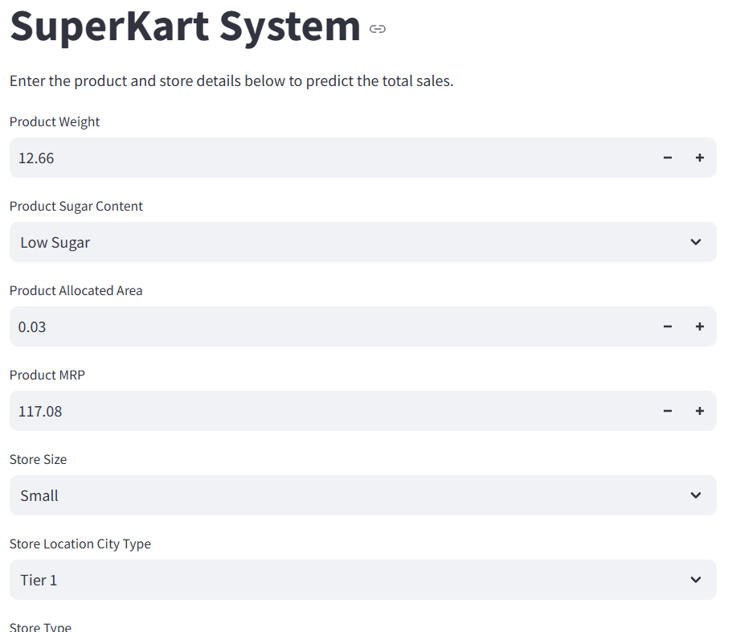

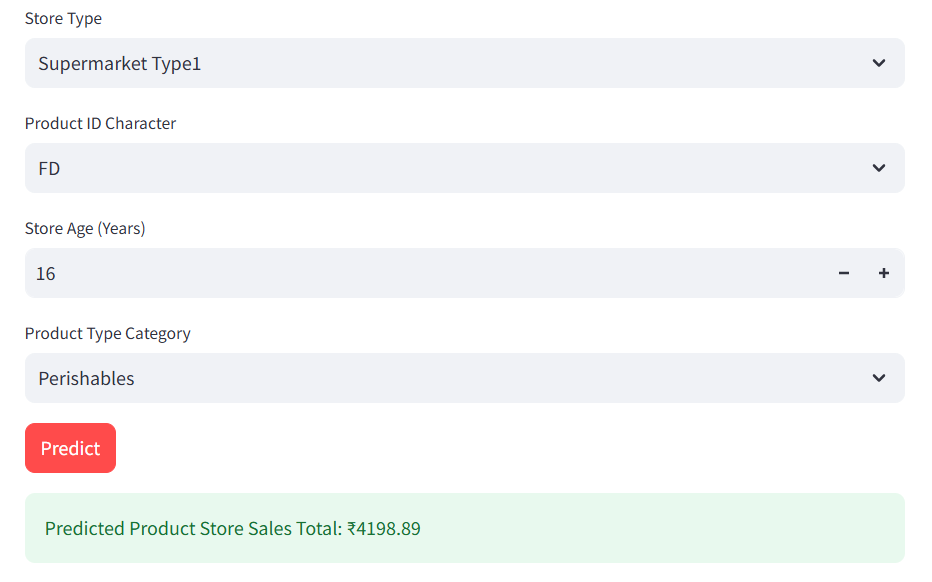

#### **App prediction for Batch file**

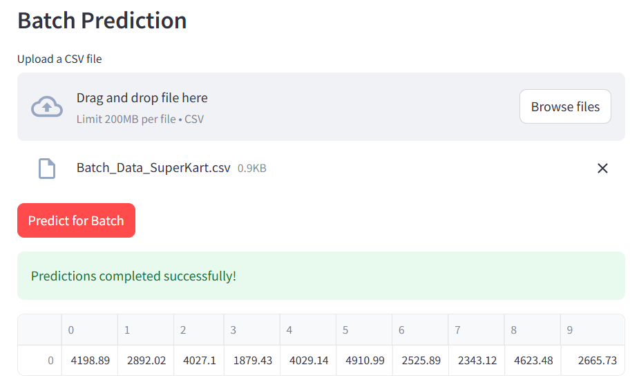

# **Actionable Insights and Business Recommendations**

- **Flexibility and Scalibility** - As we have separated both frontend and backend, we can easily update and scale up each component independently. This gives us flexibility to change or update our user interface without touching our backend or prediction model and this applies vice versa as well. This also means we can make changes to our backend to handle bulk request without making any changes to frontend. This also helps us in determining any issues occurred independently without touching other component. In short we can say, we are coupling two components to make a one system and easily decoupled it whenever situation arises.
- **Technology flexibility** - Here we are using decoupled strategy for our backend and frontend system. We have deployed streamlit for the interactive frontend and flask for the backend. In future, if we come across any system which works better for frontend or backend, we can easily update our system without getting worried about it impact on other component. So this decoupling gives us flexibility to choose best option for our application.
- **Reusability of the backend api** - We can use our backend prediction model across other systems by integrating it with other applications or services. We can even share it with other users as well. Instead of limiting backend api use to single prediction application, we can efficiently extend its benefits to other applications. This saves us lot of resources like manpower, cost and time. Actually this will help in generating revenue.
- **Portablility via containers** - We have deployed our model as backend and frontend containers which are easily portable and contains model, dependencies, configurations and runtime environment. This helps in easy deployment in other systems and eliminates compatibility issues. Certainly it makes deployment easier and hassle free.

**Business Recommendation** -

Now that we have deployed our interactive sales prediction model, we can provide some recommendation to business which will help them in revenue generation, inventory management and introduce store level promotion.

- Inventory Management - Using this sales forecast model, superkart can plan for inventory for products for the store based on demand in better way. This will eliminate situation of the overstock and understock in the stores. Stores will be able to replenish in demand products on time.
- Allocation space - Shelf space should be allocated based on the demand of the product. This model will help in finding the in demand product and in demand product should be allocated more display space as compare to other products. It will help in increase revenue generating opportunities.
- Store Based Promotion and Pricing - Store can use promotion and pricing to move overstocked products and also to attract more customers based on the competitive pricing. Based on there location they can price there products as well.
- Supply Chain consistency - Based on the sales forecast, stores can maintain there supply chain efficiently. They can make collaboration with the vendors and plan there logistics accordingly. Planning always helps in reducing the running cost and increase availability of the products as well.
- Business should collect more data which includes month wise and year wise sales as well. This will help store to predict the month which sees surge and which months are slow. This will improve planning according to month as well.

**Conclusion** - We can safely conclude, sales prediction model for the businesses are a kind of blessing. When they have predictions based on the historical data, they will be more prepare and planned accordingly. Both small and big businesses will be benefitted by the sales prediction as this will increase there net revenue generation and decrease dead stock. Inventory will be replenished on timely basis, businesses will have more space available for in demand products. At last we can say sales prediction will definitely help businesses prosper, scale there operations and create lot of opportunities for future growth.